# What Makes a Good Red? by Tyson Bryant

# Univariate Analysis

### Dataset Structure

There are 1599 wines in this dataset with 12 features (fixed acidity, volatile acidity, citric acid, chlorides, free sulfur dioxide, total sulfur dioxide, density, pH, sulphates, and quality).

Observations: - Most wines have less than 11% alcohol by volume - Median wine quality is 6 and the highest score possible is 8 - Wines tend to be low in volatile acidity and free SO2, variables known to affect flavor in high concentrations - Sugar, salt, sulpher dioxide, alcohol, and acidity ratings beside pH are all right-skewed

### Dataset Main Feature: Quality

The main feature of interest in this data is the quality rating. Though subjective, quality offers a glimpse of how the wine compares to other wines. By investigating relationships between physiochemical properties and quality ratings, this investigation aims to identify variables that might be useful in building a predictive model of wine quality based on phyiochemical properties.

### Other Variables of Interest

Variables in the dataset that are known to affect the flavor of wine include free SO2, volatile acidity, citric acid, sugar, and salt. Since free SO2 levels in most wines are under the 50 ppm threshold needed to be detectable in wine, that feature in this dataset may not be useful in predicting quality. Sugar and salt (chlorides) both occur at low levels with little dispersion for the bulk of wines.

# Bivariate Plots Section

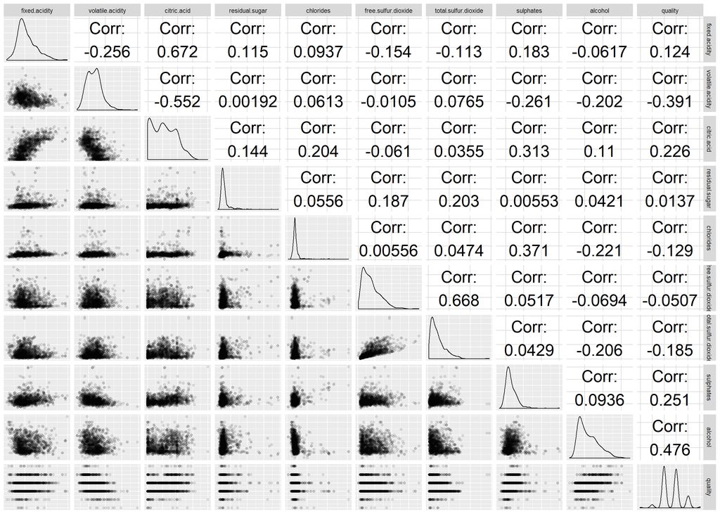

Alcohol and volatile acidity have the strongest correlations to quality followed by sulphates and citric acid. Alcohol, sulphates, and citric acid are positively correlated with quality whereas volatile acidity is negatively correlated with quality. There are also a few seemingly obvious correlations. Citric acid is positively and negatively correlated with fixed and volatile acidity, respectively. Free and total SO2 also are correlated, which makes sense because the latter includes the former.

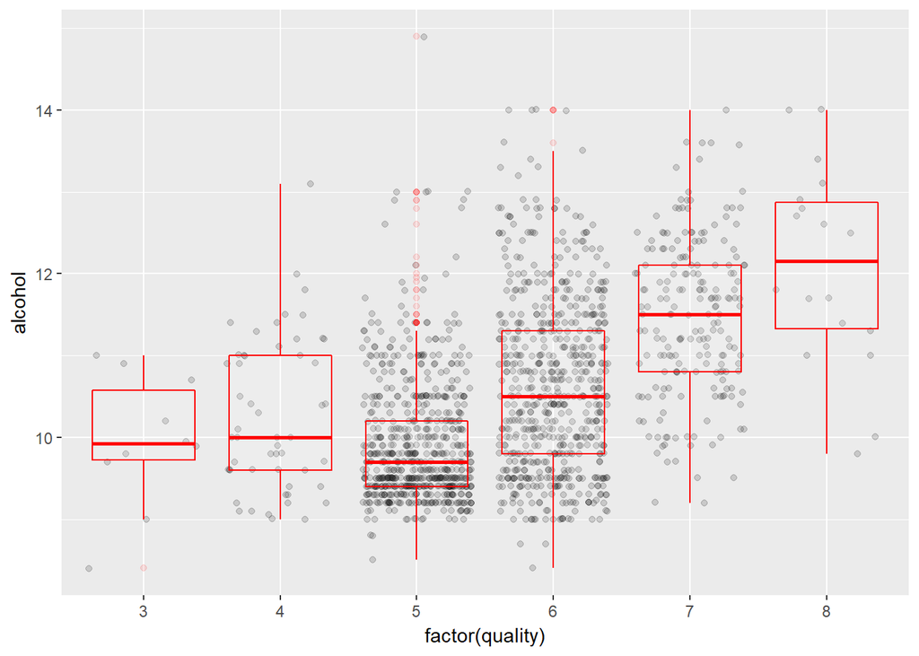

Here we see how quality tends to rise with alcohol content. Alcohol and quality share a moderate positive correlation (.476).

Wines with the highest quality rating have the highest median alcohol content and wines with lowest quality rating have the lowest median alcohol content with the exception of wines of quality rating 5. This may be due to the higher variance associated with the most popular wine rating. We can see there are a lot of high outliers at rating 5.

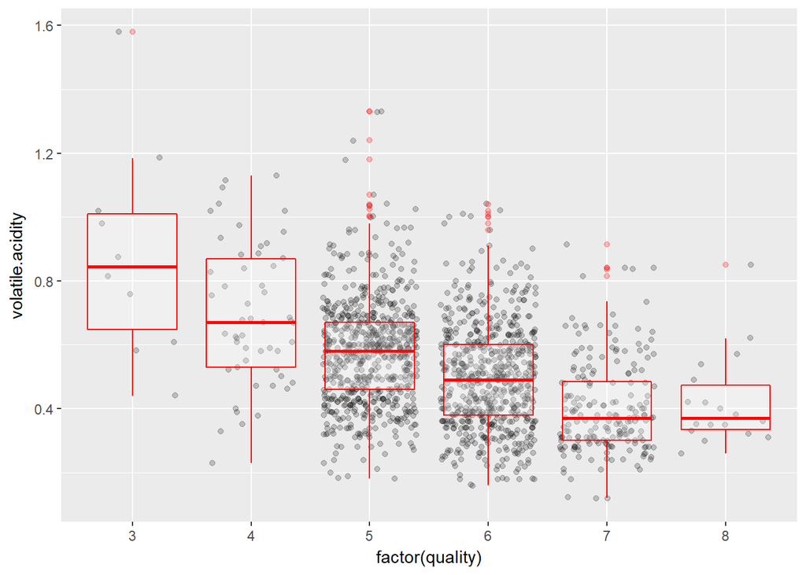

And here we see how quality tend to drop as volatile acidity rises. The lowest quality rating (3) has the highest mean volatile acidity and the highest ratings (7, 8) have the lowest median volatile acidity levels. As discussed above, volatile acidity can lead to an unpleasant bitter taste in wines if too high in concentration. We can almost see a dropping off point where higher rated wines of quality 7 and 8 don’t have volatile acidity values but average wines of quality 6 or lower do. This magic number appears to be 0.6-0.7. This is a moderate negative correlation (-.391).

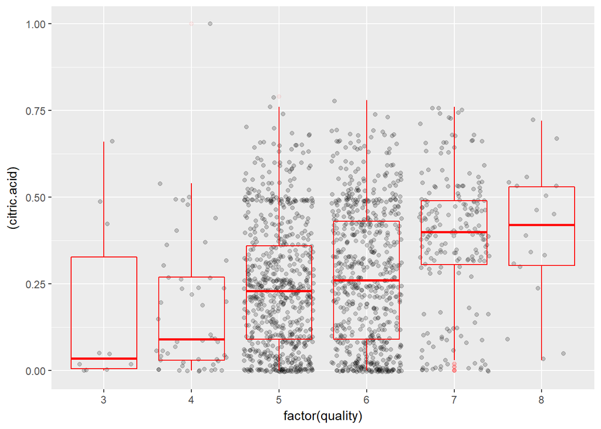

As with alcohol and volatile acidity, the expectations implied by the correlation (.226) between quality and citric acid bear out. The higher the quality rating, the higher the median level of citric acid.

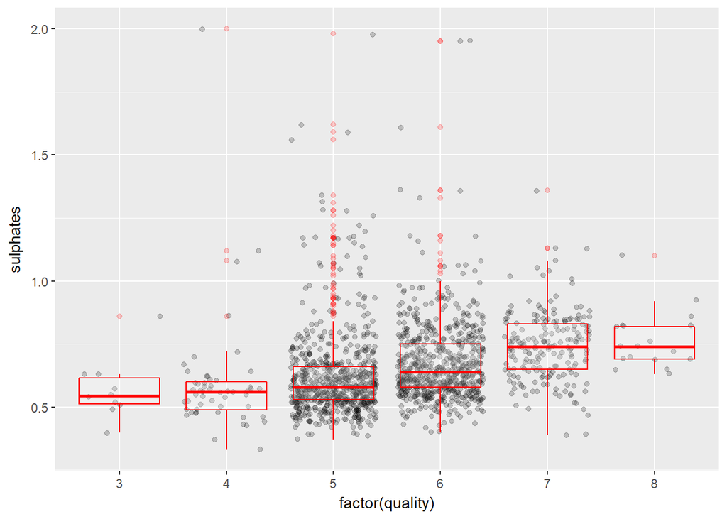

The scatterplot looking at the relationship between sulphates and quality seemed to show that it was beneficial up to a certain point. Higher quality wines tend to have a lot more sulphate values under 1 than over and wines with really high sulphate levels tended to be of average quality rating. Moving a rating of 7 to 8, the mean sulphate level was the same, about .75, and much more tightly clustered. The correlation between quality and sulfate is weak (.251).

# Bivariate Analysis

### Quality Relationships

Quality ratings were positively correlated with alcohol content, citric acid, and sulphate levels and were negatively correlated with volatile acidity.

### How do variables relate with each other?

Citric acid and volatile acidity were negatively correlated. This could mean that the positive correlation between citric acid and quality might actually be from volatile acidity, which tends to be in lower concentration when citric acid is high and overall seems to explain more of the variation in quality than citric acid does.

### The Strongest Relationship

The strongest relationship with quality in the dataset was alcohol content.

# Multivariate Plots Section

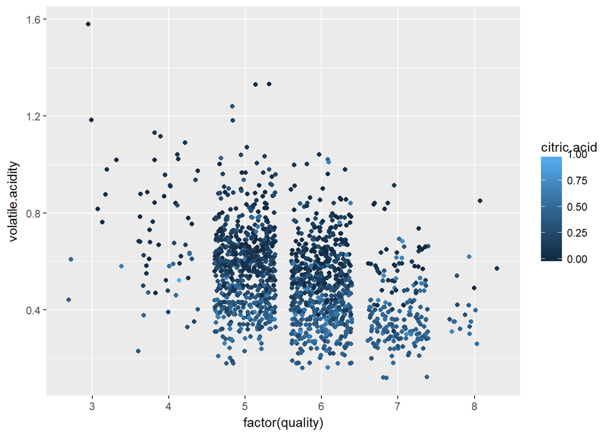

It’s going to be difficult to see patterns with this gradient color scheme. I will cut the continuous variables into categorical ones to make it easier to see any patterns.

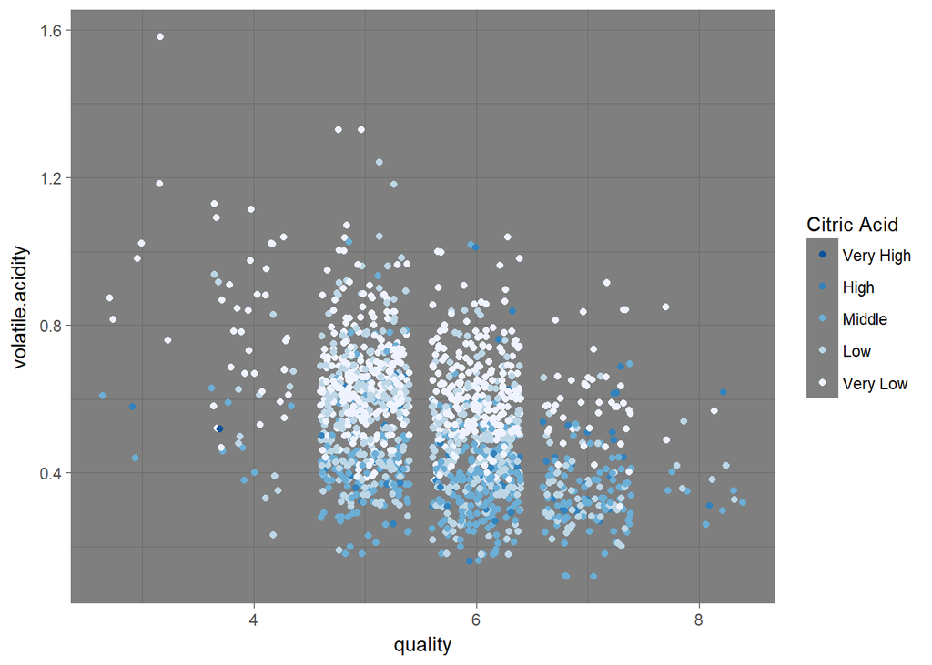

```r
# First, let's set up the labels we'll use on the cuts
buckets <- c("Very Low","Low", "Middle","High","Very High")

# Then use cut() to create a new variable from citric.acid with 5 levels
# right=FALSE is used to avoid NA values from closing the interval on the right
rw$citric.acid.buckets <- cut(rw$citric.acid, breaks = 5,
                              include.lowest = TRUE, right = FALSE)

# Label the five levels using the buckets list... badump-tiss.
levels(rw$citric.acid.buckets) <- buckets

# Below, repeated for the remaining variables
rw$sulphates.buckets <- cut(rw$sulphates, breaks = 5,
                            include.lowest = TRUE, right = FALSE)
levels(rw$sulphates.buckets) <- buckets

rw$volatile.acidity.buckets <- cut(rw$volatile.acidity, breaks = 5,
                                   include.lowest = TRUE, right = FALSE)
levels(rw$volatile.acidity.buckets) <- buckets
```

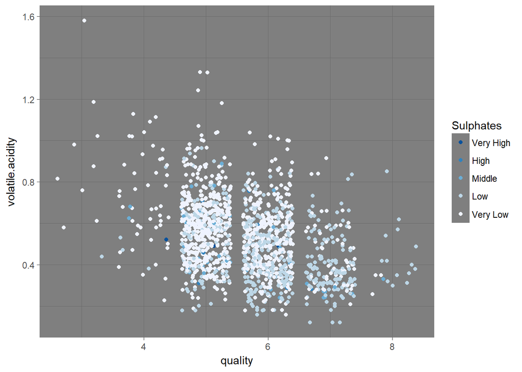

Accounting for a constant volatile acidity, higher sulphates do tend to belong to higher rated wines.

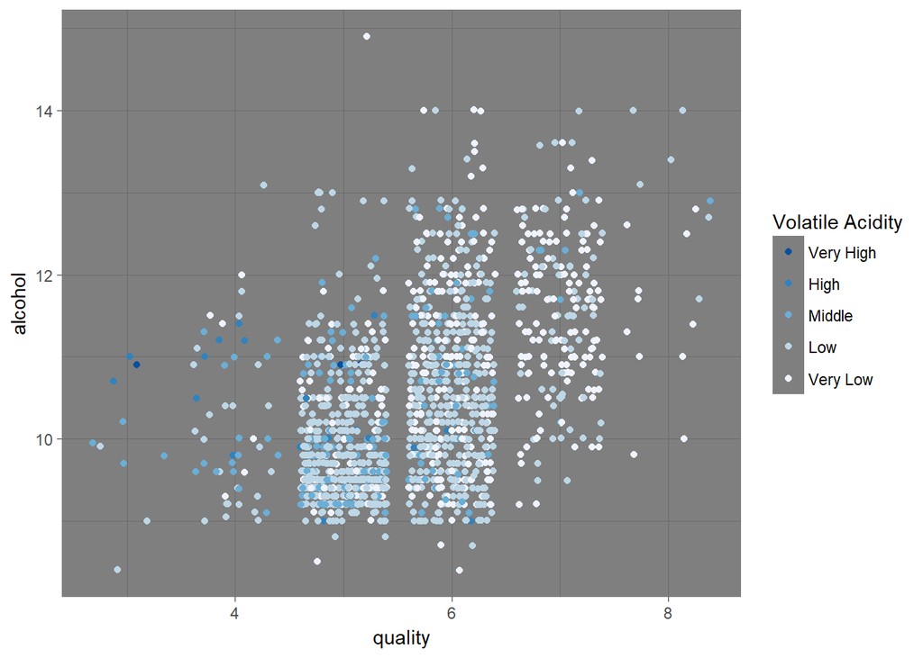

Accounting for a constant alcohol level, lower volatile acidity appears to be associated with higher quality ratings.

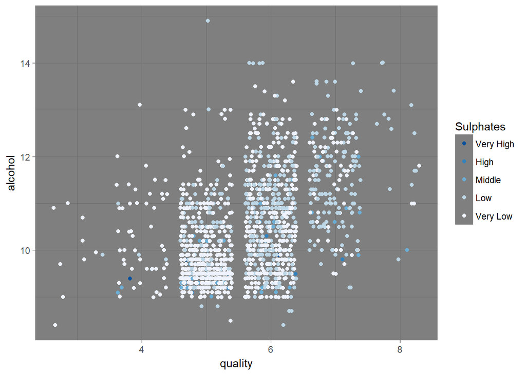

Higher sulphates appear to be tied to higher quality ratings at a given alcohol level.

# Multivariate Analysis

### Cutting Variables

In order to make it easier to see patterns in differing levels of volatile acidity, citric acid, and sulphates, they were all cut into variables with five levels ranging from “very Low” to “Very High.”

### Acid Overlap: Toward a Predictive Model

In the multivariate plots we saw that citric acid doesn’t seem to be doing much explaining of its own, preferring instead to inverse piggy-back on volatile acidity.

This exploration suggests that a model could be made to predict quality based on alcohol content, volatile acidity, and sulphates. Sulphates, however, might have non-linear relationship with quality.

# Final Plots and Summary

### Plot One

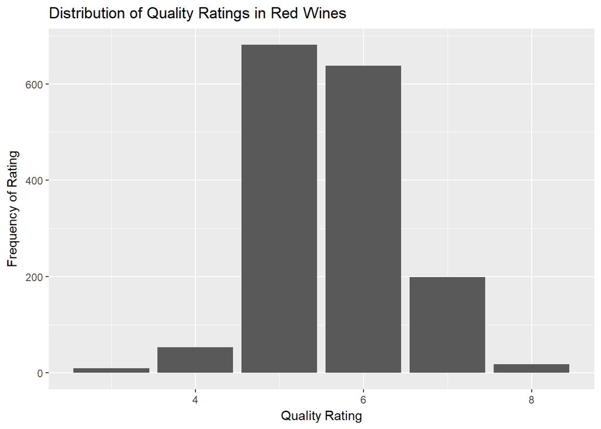

### Description One

While simple, this plot reveals the structure of our main feature. Quality scores in the dataset are on a normal curve with the grand majority of the wines rated average in quality at 5 or 6.

### Plot Two

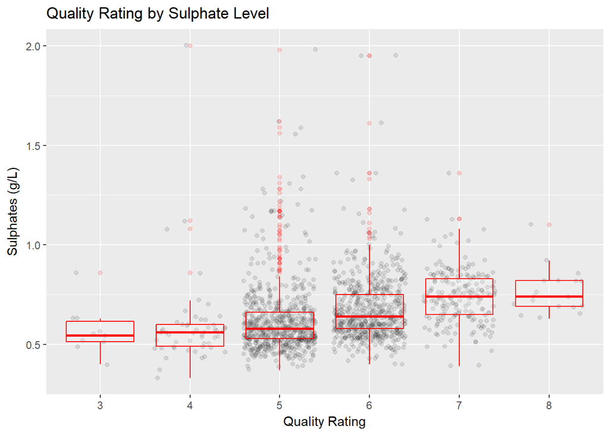

### Description Two

This plot helps to explain the relationship between sulphates and quality. Wines with higher sulphates tend to be higher rated wines as well, to a certain point. At a sulphate level of about .75, the average quality score begins to level off and possibly dip. The highest rated wines center on this .75 level and have lower variance. This suggests that perhaps sulphates can contribute to CO2 levels and serve antimicrobial and antioxidant functions up to a level of about .75 but that higher levels have no beneficial effect and may even start to harm taste.

### Plot Three

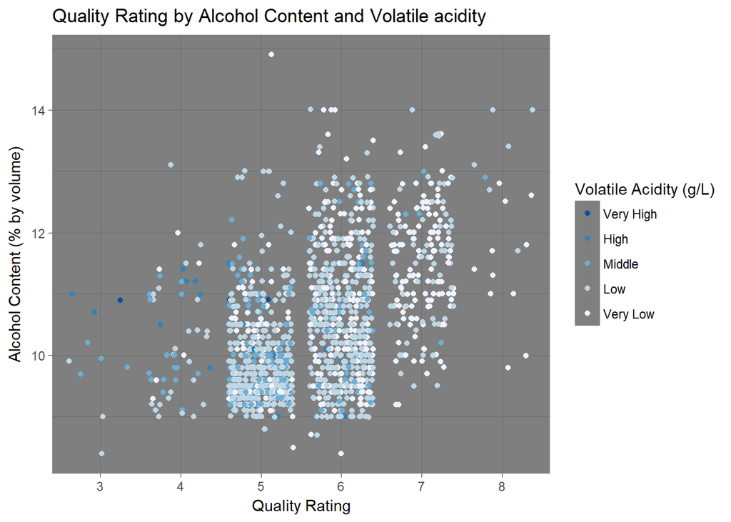

### Description Three

This plot reveals that volatile acidity’s relationship with quality is not mediated by alcohol levels. That is, at any given alcohol level, higher quality wines will tend to have lower volatile acidity. Since alcohol and volatile acidity have the strongest correlations with quality, this plot suggests that both volatile acidity and alcohol should be included in a linear model to predict quality.

# Reflection

After looking at histograms and summaries to get an intuition for the structure of the 12 variables, I created a scatterplot matrix to let the data tell me where my investigation was most likely to have the biggest impact. From that matrix I learned that quality had two moderate correlations, alcohol and volatile acidity, and two weak correlations, citric acid and sulphates.

In taking a closer look I found that the relationship between sulphates and quality might not be simply linear. Higher quality wines tend to to have higher sulphate levels until the jump from rating 7 to rating 8 where sulphates leveled off at, and clustered more tightly around .75 sulphates.

Finally, I looked at the variables of interest across rates of other variables using scatterplots with points colored based on their score in a third variable. This is where I ruled out citric acid as factor likely to make sense in a model because it changed with volatile acidity. At first, when using the default gradient color scheme with the continuous data, it was difficult to see any patterns. So, I cut the variables volatile acidity, citric acid, and sulphates into categories and colored scatterplots by those categories to try to make it easier to see how different levels of each variable compared with each other. I was then able to use a color scheme from RColorBrewer to see that citric acid was pretty much saying the same thing as volatile acid, a powerful finding for simplifying a potential model.

Based on this analysis I would suggest using alcohol and volatile acidity to make a simple linear model to predict quality. Another option would be to further explore the seemingly non-linear relationship between sulphates and quality and add that to alcohol and volatile acidity in a more complex model. However, considering that the correlation between sulphates and quality is weak, improvements may not be worth the extra time and energy to construct such a model.